# Simulation result

## 1. case 1

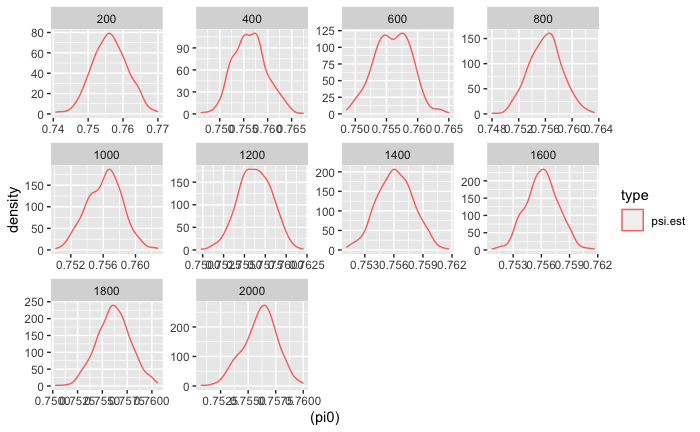

```r
## true data background
# W <- matrix(runif(n*3, 0, 1), ncol=3)
# A <- rbinom(n, size = 1, prob = pi0(W))
# if(null.sims) {
#   Y <- rbinom(n, size = 1, prob = mu0.null(A, W))
#   psi0 <- mean((mu0.null(1,W) - mu0.null(0,W))^2)
#   theta0 <- var((mu0.null(1,W) - mu0.null(0,W)))
# } else {
#   Y <- rbinom(n, size = 1, prob = mu0(A, W))
#   psi0 <- mean((mu0(1,W) - mu0(0,W))^2)
#   theta0 <- var((mu0(1,W) - mu0(0,W)))
# }

# ests.sim.1 <- ests.sim(200*c(1:10), 1:500, control = list(conf.int = TRUE), null.sims=FALSE, out.glm=TRUE)
load("ests.sim.1.Rdata")
ggplot(subset(ests.sim.1, (type %in% 'psi.est'))) +
  geom_density(aes((pi0), color=type)) +
  facet_wrap(~n, scales='free')
```

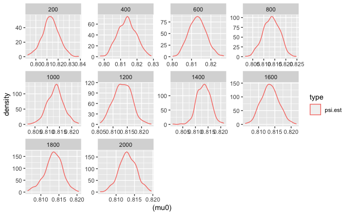

```r
ggplot(subset(ests.sim.1, (type %in% 'psi.est'))) +
  geom_density(aes((mu0), color=type)) +
  facet_wrap(~n, scales='free')
```

### 1.1 rates of convergence

$$n^\frac{1}{2}(\psi_n-\psi_0)\xrightarrow{d}N(0,\sigma_{0,\psi}^2)$$
$$n^\frac{1}{2}(\theta_n-\theta_0)\xrightarrow{d}N(0,\sigma_{0,\theta}^2)$$
#### 1.1.1 psi

```r
ggplot(subset(ests.sim.1, (type %in% 'psi.est'))) +
  geom_density(aes(sqrt(n) * (est - psi0), color=type)) +
  facet_wrap(~n, scales='free')
```

[output not shown]

#### 1.1.2 theta

```r
ggplot(subset(ests.sim.1, (type %in% 'theta.est'))) +
  geom_density(aes(sqrt(n) * (est - theta0), color=type)) +
  facet_wrap(~n, scales='free')
```

[output not shown]

- Both $\psi_n$ and $\theta_n$ didn’t seem to converge to Normal distribution as n goes to infinity.

**How about the performance of nuisance parameters?**

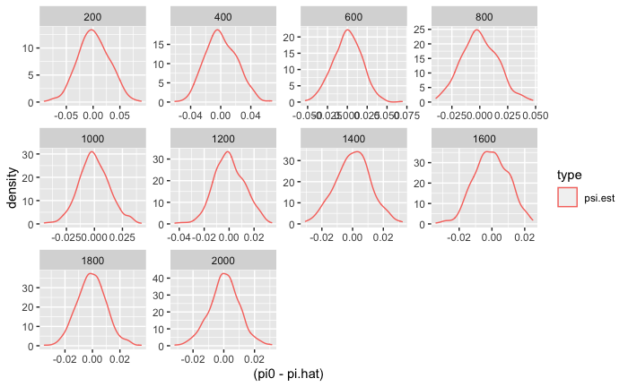

```r
ggplot(subset(ests.sim.1, (type %in% 'psi.est'))) +
  geom_density(aes((pi0 - pi.hat), color=type)) +
  facet_wrap(~n, scales='free')
```

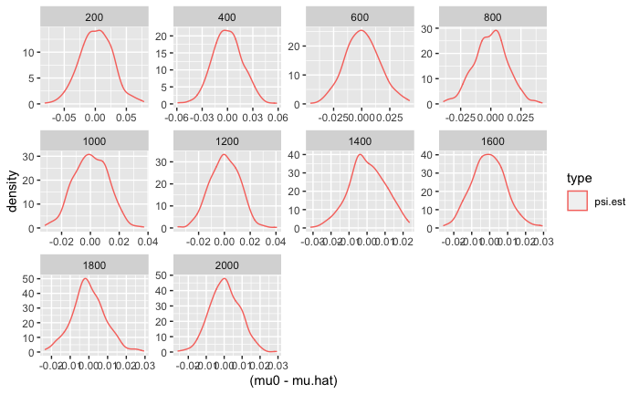

```r
ggplot(subset(ests.sim.1, (type %in% 'psi.est'))) +
  geom_density(aes((mu0 - mu.hat), color=type)) +
  facet_wrap(~n, scales='free')
```

### 1.2 estimate and confidence interval

```r
psi.summaries.1 <- ddply(subset(ests.sim.1, (type %in% 'psi.est')), .(n, type), summarize, na = sum(is.na(est)),
                   coverage = mean(ll <= psi0 & psi0 <= ul, na.rm=TRUE),
                   bias = mean(est - psi0, na.rm=TRUE),
                   var = var(est, na.rm=TRUE),
                   mse = mean((est - psi0)^2, na.rm=TRUE))
```

#### 1.2.1 psi

**Wald-type**

```r
library(ggplot2)
p1 <- ggplot(psi.summaries.1) +
  geom_line(aes(n, coverage, color=type)) +
  geom_hline(yintercept=.95)

p2 <- ggplot(psi.summaries.1) +
  geom_line(aes(n, sqrt(n) * bias, color=type))

p3 <- ggplot(psi.summaries.1) +
  geom_line(aes(n, n * mse, color=type))

p4 <- ggplot(psi.summaries.1) +
  geom_line(aes(n, n * var, color=type)) +
  coord_cartesian(ylim=c(0,1))

library(gridExtra)
grid.arrange(p1, p2, p3, p4, ncol=2)

ggplot(psi.summaries.1) +
  geom_line(aes(n, bias, color=type))
```

[output not shown]

- The Wald-type CI coverages are below 0.95.
- As n increases, the coverage is going down.
- (have already check the formula and the formula should be correct).
- The absolute value of bias is getting larger even if plotting with bias instead of sqrt(n)*bias.

```r
ests.sim.1$psi.coverage <- (ests.sim.1$ll <= ests.sim.1$psi0) & (ests.sim.1$psi0 <= ests.sim.1$ul)
ests.sim.1$theta.coverage <- (ests.sim.1$ll <= ests.sim.1$theta0) & (ests.sim.1$theta0 <= ests.sim.1$ul)
ggplot(subset(ests.sim.1, (type %in% 'psi.est') & (n %in% c(200, 600, 1000, 2000)) &
                (psi.coverage ==FALSE))) +
  geom_linerange(mapping = aes(x=j, ymin=ll, ymax=ul)) +
  geom_point(mapping=aes(x=j, y=psi0), size=1, col="red") +
  facet_wrap(~n, scales='free')
```

[output not shown]

- So I plot out all the Confidence Intervals that fails to cover the $\psi_0$.
- The estimator $\psi_n$ underestimate the real $\psi_0$.

**Bootstrap**

```r
# ests.sim.2 <- ests.sim(200*c(1:10), 1:500, control = list(conf.int = TRUE, conf.int.type = 'boot'), null.sims=FALSE, out.glm=TRUE)
load("ests.sim.2.Rdata")
# analysis
psi.summaries.2 <- ddply(subset(ests.sim.2, (type %in% 'psi.est')), .(n, type), summarize, na = sum(is.na(est)),
                   coverage = mean(ll <= psi0 & psi0 <= ul, na.rm=TRUE),
                   bias = mean(est - psi0, na.rm=TRUE),
                   var = var(est, na.rm=TRUE),
                   mse = mean((est - psi0)^2, na.rm=TRUE))

ggplot() +
  geom_line(data = psi.summaries.1, aes(n, coverage, colour='wald-type')) +
  geom_line(data = psi.summaries.2, aes(n, coverage, colour='bootstrap')) +
  geom_hline(yintercept=.95)
```

[output not shown]

- The Bootstrap CI coverages also below 0.95.

```r
ests.sim.2$psi.coverage <- (ests.sim.2$ll <= ests.sim.2$psi0) & (ests.sim.2$psi0 <= ests.sim.2$ul)
ests.sim.2$theta.coverage <- (ests.sim.2$ll <= ests.sim.2$theta0) & (ests.sim.2$theta0 <= ests.sim.2$ul)
ggplot(subset(ests.sim.2, (type %in% 'psi.est') & (n %in% c(200, 600, 1000, 2000)) &
                (psi.coverage ==FALSE))) +
  geom_linerange(mapping = aes(x=j, ymin=ll, ymax=ul)) +
  geom_point(mapping=aes(x=j, y=psi0), size=1, col="red") +
  facet_wrap(~n, scales='free')
```

[output not shown]

- There are more Bootstrap confidence intervals overestimating the $\psi_0$ when n is small.

#### 1.2.2 theta

**Wald-type**

```r
theta.summaries.1 <- ddply(subset(ests.sim.1, (type %in% 'theta.est')), .(n, type), summarize,
                       na = sum(is.na(est)),
                       coverage = mean(ll <= theta0 & theta0 <= ul, na.rm=TRUE),
                       bias = mean(est - theta0, na.rm=TRUE),
                       var = var(est, na.rm=TRUE),
                       mse = mean((est - theta0)^2, na.rm=TRUE))
p1 <- ggplot(theta.summaries.1) +
  geom_line(aes(n, coverage, color=type)) +
  geom_hline(yintercept=.95)

p2 <- ggplot(theta.summaries.1) +
  geom_line(aes(n, sqrt(n) * bias, color=type))

p3 <- ggplot(theta.summaries.1) +
  geom_line(aes(n, n * mse, color=type))

p4 <- ggplot(theta.summaries.1) +
  geom_line(aes(n, n * var, color=type)) +
  coord_cartesian(ylim=c(0,1))

library(gridExtra)
grid.arrange(p1, p2, p3, p4, ncol=2)

ggplot(theta.summaries.1) +
  geom_line(aes(n, bias, color=type))
```

[output not shown]

**Bootstrap**

```r
theta.summaries.2 <- ddply(subset(ests.sim.2, (type %in% 'theta.est')), .(n, type), summarize,
                       na = sum(is.na(est)),
                       coverage = mean(ll <= theta0 & theta0 <= ul, na.rm=TRUE),
                       bias = mean(est - theta0, na.rm=TRUE),
                       var = var(est, na.rm=TRUE),
                       mse = mean((est - theta0)^2, na.rm=TRUE))

ggplot() +
  geom_line(data = theta.summaries.1, aes(n, coverage, colour='wald-type')) +
  geom_line(data = theta.summaries.2, aes(n, coverage, colour='bootstrap')) +
  geom_hline(yintercept=.95)
```

[output not shown]

- Bootstrap confidence levels seem to be weird.

```r
ggplot(subset(ests.sim.2, (type %in% 'theta.est') & (n %in% c(200, 600, 1000, 2000)) &
                (psi.coverage ==FALSE))) +
  geom_linerange(mapping = aes(x=j, ymin=ll, ymax=ul)) +
  geom_point(mapping=aes(x=j, y=psi0), size=1, col="red") +
  facet_wrap(~n, scales='free')
```

[output not shown]

**Why Bootstrap confidence levels seem to be so weird?**

```r
# unit test
null.sims <- FALSE

n <- 1000
set.seed(39338064)
W <- matrix(runif(n*3, 0, 1), ncol=3)
A <- rbinom(n, size = 1, prob = pi0(W))
if(null.sims) {
  Y <- rbinom(n, size = 1, prob = mu0.null(A, W))
  psi0 <- mean((mu0.null(1,W) - mu0.null(0,W))^2)
  theta0 <- var((mu0.null(1,W) - mu0.null(0,W)))
} else {
  Y <- rbinom(n, size = 1, prob = mu0(A, W))
  psi0 <- mean((mu0(1,W) - mu0(0,W))^2)
  theta0 <- var((mu0(1,W) - mu0(0,W)))
}

# use `glm` for both pi.hat and mu.hat in simple unit test
prop.reg <- gam(A ~ s(W[,1]) + s(W[,2]) + s(W[,3]), family = 'binomial')
pi.hat <- prop.reg$fitted.values
AW <- cbind(A, data.frame(W))
mu.reg <- glm(Y ~ ., data=AW, family='binomial')
mu.hat <- mu.reg$fitted.values
mu1.hat <- predict(mu.reg, newdata = cbind(data.frame(A = 1),
                                           data.frame(W)), type = 'response')
mu0.hat <- predict(mu.reg, newdata = cbind(data.frame(A = 0),
                                           data.frame(W)), type = 'response')
mu.hats <- data.frame(mu1=mu1.hat, mu0=mu0.hat)
# wald
ret1 <- htem.estimator(A, W, Y, control = list(conf.int = TRUE,
                                       pi.hat = pi.hat, mu.hats = mu.hats))
# bootstrap
ret2 <- htem.estimator(A, W, Y, control = list(conf.int = TRUE, conf.int.type='boot',
                                               pi.hat = pi.hat, mu.hats = mu.hats))

cat('theta0:', theta0)
# why bootstrap CI didn't work?
theta.test.vector <- rep(0, 500)
for (i in 1:500){
  boot.inds <- sample(1:n, n, replace=TRUE)

  boot.pi.hat <- pi.hat[boot.inds]
  boot.mu.hats <- mu.hats[boot.inds,]
  boot.ret <- htem.estimator(A[boot.inds], W[boot.inds], Y[boot.inds],
                             control = list(pi.hat = boot.pi.hat,
                                            mu.hats = boot.mu.hats,
                                            conf.int = FALSE))
  theta.test.vector[i] <-boot.ret$est[2]
}
density(theta.test.vector)
quantile(theta.test.vector, c(0.025,0.975))
```

[output not shown]

- Since we do bootstrap based on pi.hat and mu.hats, so the estimator won’t vary too much.
- The estimator itself also always underestimate the true value.
- Hence it is difficult to cover the true value.

## 2. case 2

- null.sims=TRUE it means that mu0 has nothing to do with A